# Pose Estimator for Three Wheeled Platform

## Introduction (from Brain Corp)

You have been assigned to write a pose estimator designed to estimate the 2D position of the mobile platform (x, y, heading) based on odometry information using wheel encoder and imu data. The mobile platform is a wheeled tricycle with a steering mechanism that has been attached to the front wheel. r is a distance from the front wheel to back axis, d is a distance between the rear wheels.

[figure not shown]

We use a right handed coordinate system, where Z is up, X is forward and Y is to the left of the robot, with positive Yaw (around the z axis) being counter-clockwise and negative yaw being clockwise. The front wheel can rotate up to 90 degrees in both directions around the Z axis. The platform is moving on a 2D-plane (constant z=0). The mobile platform is expected to go straight when the steering angle is 0.

Parameters of the tricycle:

- Front wheel radius = 0.2 m
- Back wheels radius = 0.2 m
- Distance from front wheel to back axis (r) = 1m
- Distance between rear wheels (d) = 0.75m

A traction motor has been attached to the front wheel and is equipped with an encoder with a resolution of 512 ticks per revolution. The steering mechanism also includes an absolute encoder which provides an estimation of the steering angle (in radians).

The pose of the platform is a pose of the center of the rear axis. Initial pose is assumed to be (x, y, heading) = (0, 0, 0).

At each step, the new estimate of the position of the mobile platform is obtained through a call to an estimate method with the following API:

```
estimate (time, steering_angle, encoder_ticks, angular_velocity) returns estimated_pose (x, y,
heading)
```

| Input | Description | Unit |
| --- | --- | --- |
| time | Time of reading input data | sec |
| steering_angle | Steering wheel angle | rad |
| encoder_ticks | Number of ticks from the traction motor encoder | Ticks(integer) |
| angular_velocity | Reading from a gyroscope measuring the rotation velocity of the platform around the Z axis | Rad/s |

| Output | Description | Unit |
| --- | --- | --- |
| estimated_pose | New estimated pose. Tuple (x,y, heading) representing the estimated pose of the platform | (m,m,rad) |

## Approach

### Establishing Relations Between Variables

We can assume that if the platform moves with a constant steering angle it will follow a circular path. The front wheel moves in the direction of the steering angle and the back wheels move in the direction of the heading. This means the rear axel will follow a circular path with a smaller radius of curvature ($L_2$) than the front wheel ($L_1$) as shown in the diagram below.

[figure not shown]

$\theta$ and $\alpha$ represent the platform's heading and steering angle respectively and **v** represents the velocity vector of the front wheel. The non-bolded $v$ is the speed. As before d and r represent the distance between the rear wheels and the distance between the front wheel and back axel respectively.

We calculate the radii of curvatures $L_1$ and $L_2$: $$L_1 = \frac{r}{sin(\alpha)}\label{L1}\tag{1}$$

$$L_2 = \frac{r}{tan(\alpha)}\label{L2}\tag{2}$$

Using v, the rate of change of the heading $\omega$ is calculated: $$\omega = \dot{\theta} = \frac{v}{L_1}\tag{3}$$

$$\omega = \frac{v sin(\alpha)}{r}\label{omega}\tag{4}$$

Lastly, the position of the center of the rear axel is calculated assuming $\theta_{_0} = 0$: $$\theta(t) = \omega t\label{theta}\tag{5}$$

$$x = L_2 sin(\theta(t)) = \frac{r}{tan(\alpha)} sin(\theta(t))\label{x}\tag{6}$$$$y = L_2 (1 - cos(\theta(t))) = \frac{r}{tan(\alpha)} (1 - cos(\theta(t)))\label{y}\tag{7}$$

### Discretization and Estimation

Each call to the `estimate()` method is discrete so the estimation must take this into account. The data available from the sensors are the times($t_i$), steering angles($\alpha_i$), encoder ticks($ticks_i$), and angular velocities($\omega_i$) where $i$ represents the $ith$ call to the `estimate()` method. The time and encoder data are accumalative.

The two cases to consider for a call to `estimate()` are $\alpha_i \neq 0$(turning) and $\alpha_i = 0$(straight).

#### Case 1: Turning

In this case, the encoder ticks are unnecessary since the change of the platform's pose can be calculated using just the time,steering angle, and angular velocity. A more accurate pose could be estimated using some sensor fusion that utilizes the encoder data but for the scope of this project I forgo any sensor fusion algorithms.

First, calculate $\theta_i$: $$\Delta t = t_i - t_{i-1}\tag{8}$$

$$\Delta \theta = \omega \Delta t\tag{9}$$$$\theta_i = \theta_{i-1} + \Delta \theta\tag{10}$$

From Eqns. $\ref{x}$ and $\ref{y}$: $$\Delta x = \frac{r}{tan(\alpha_i)} (sin(\theta_i) - sin(\theta_{i-1}))\tag{11}$$

$$\Delta y = \frac{r}{tan(\alpha_i)} (-cos(\theta_i) + cos(\theta_{i-1}))\tag{12}$$$$x_i = x_{i-1} + \Delta x\tag{13}$$$$y_i = y_{i-1} + \Delta y\tag{14}$$$$estimate\_pose = (x_i,y_i,\theta_i)\tag{15}$$

#### Case: 2 Straight Line

In the case that $\alpha_i = 0$, the above method won't work as it only works for when the platform is in a turn. To estimate the new pose, only the time and encoder ticks are necessary.

The platform's heading is left unchanged: $$\theta_i = \theta_{i-1}\tag{16}$$

In order to calculate the distance travelled, an approximation of the wheel speed, $v$, is calculated: $$\Delta ticks = ticks_i - ticks_{i-1}\tag{17}$$

$$v \approx \frac{2\pi R}{\gamma}\times\frac{\Delta ticks}{\Delta t}\tag{18}$$

where $R$ is the radius of front wheel and $\gamma$ is the number of ticks per revolution of the front wheel.

$$\Delta x = v cos(\theta_i) \Delta t\tag{19}$$$$\Delta y = v sin(\theta_i) \Delta t\tag{20}$$$$x_i = x_{i-1} + \Delta x\tag{21}$$$$y_i = y_{i-1} + \Delta y\tag{22}$$$$estimate\_pose = (x_i,y_i,\theta_i)\tag{23}$$

### Code Implementation

Since the data and pose estimation from the previous call to `estimate()` are required to calculate the new pose estimation, the platform class defined in `platform.h` is used to create a platform object that contains the public method `estimate()` as well as private member variables to keep track of the most recent pose estimation and sensor data that are updated upon each call to `estimate()`. For further information on how to use the platform class see "README.pdf".

## Testing

For the following tests, excluding the **Variable Data Test**, the data passed to the `estimate()` method is generated using the equations from the previous sections.

### Import Python Packages

```python
import numpy as np
import matplotlib.pyplot as plt
```

### Test 1: Line Test

The generated data simulates the platform moving at a constant speed of $5\ m/s$ with $\alpha = 0$ for a duration of $1\ s$. This should produce a flat line path that extends to the right by $5\ m$.

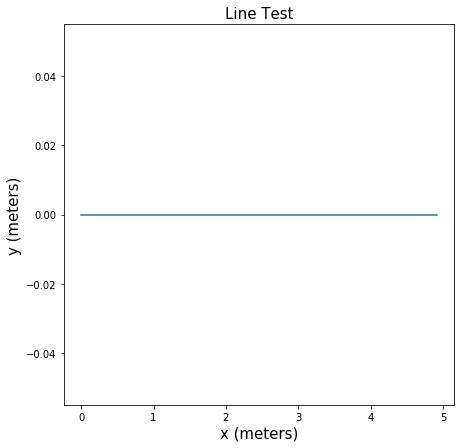

```python
points = np.genfromtxt('lineTest.csv',delimiter=",")
plt.figure(figsize=(7,7))
plt.plot(points[:,0],points[:,1])
plt.title("Line Test",fontsize=15)
plt.xlabel("x (meters)",fontsize=15)
plt.ylabel("y (meters)",fontsize=15)
plt.show()
```

### Test 2: Circle Test

The generated data simulates the platform moving at a constant speed of $5\ m/s$ with $\alpha = 30^\circ$ for one revolution around a circle. The expected result is a circular path with a radius of curvature of $\sqrt{3} \approx 1.7\ m$

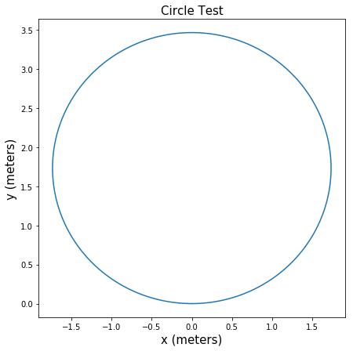

```python
points = np.genfromtxt('circleTest.csv',delimiter=",")
plt.figure(figsize=(7,7))
plt.plot(points[:,0],points[:,1])
plt.title("Circle Test",fontsize=15)
plt.xlabel("x (meters)",fontsize=15)
plt.ylabel("y (meters)",fontsize=15)
plt.show()
```

### Test 3: Figure Eight Test

The generated data simulates the platform moving at a constant speed of $5\ m/s$ with $\alpha = 30^\circ$ for one revolution around a circle and then $\alpha = -30^\circ$ for one more revolution. The expected result are two circular paths with radii of curvatures of $\sqrt{3} \approx 1.7\ m$ stacked vertically forming a figure eight shape.

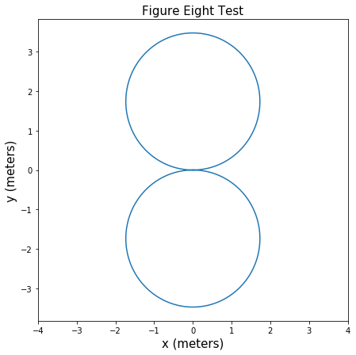

```python
points = np.genfromtxt('fig8Test.csv',delimiter=",")
plt.figure(figsize=(7,7))
plt.plot(points[:,0],points[:,1])
plt.title("Figure Eight Test",fontsize=15)
plt.xlabel("x (meters)",fontsize=15)
plt.ylabel("y (meters)",fontsize=15)
plt.xlim([-4,4])
plt.show()
```

### Test: 4 Racetrack Test

The generated data simulates a car going counter-clockwise around a race track with two parallel straightaways of equal length and two half circle turns on each side of the straightaways while at a constant speed of $7\ m/s$. During the turns $\alpha = 45^\circ$.

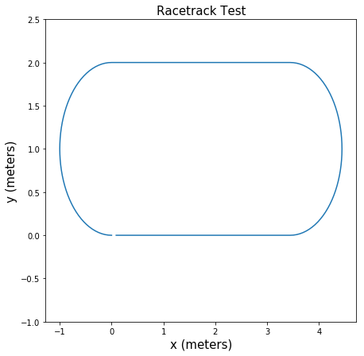

```python
points = np.genfromtxt('racetrackTest.csv',delimiter=",")
plt.figure(figsize=(7,7))
plt.plot(points[:,0],points[:,1])
plt.title("Racetrack Test",fontsize=15)
plt.xlabel("x (meters)",fontsize=15)
plt.ylabel("y (meters)",fontsize=15)
plt.ylim([-1,2.5])
plt.show()
```

### Test 5: Variable Data Test

With a real scenario, its expected that all of the sensor data can have more variation than the previous tests since it is not required for the platform to have any specific path.

To test this scenario, I use the **Wean Hall Dataset** to help generate simulated data [1]. The dataset contains gyro and encoder data from their customized four-wheeled LAGR robot. The encoder reads data from a left and a right wheel so I use just the data from the left wheel. I ignore the different value of $ticks/rev$. The gyro data does not contain the same timestamps as the encoder data nor does it contain the same number of readings as the encoder. In this test, around 4000 time and encoder readings from around the middle of the encoder file is used. The same number of gyro readings are used starting from the top of the file. Since there is no steering data, the steering angle is calculated using a calculated wheel speed and the gyro reading.

Because of this mismatch of data and the differences between the LAGR robot and the platform I don't compare the estimated pose to the pose given in the dataset. The purpose of this test is not to see if the algorithm is accurate since the line and circle tests already show this. Instead this test is meant to determine if the algorithm correctly handles varying data.

The result is expected to a smooth path without discontinuities.

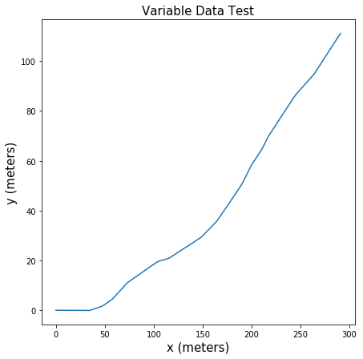

```python
points = np.genfromtxt('variableDataTest.csv',delimiter=",")
plt.figure(figsize=(7,7))
plt.plot(points[:,0],points[:,1])
plt.title("Variable Data Test",fontsize=15)
plt.xlabel("x (meters)",fontsize=15)
plt.ylabel("y (meters)",fontsize=15)
plt.show()
```

## References

[1] Alismail, H., Browning, B., & Dias, M. B. (2011). Evaluating pose estimation methods for stereo visual odometry on robots. In *the 11th Int’l Conf. on Intelligent Autonomous Systems (IAS-11)*. Retrieved from https://www.ri.cmu.edu/publication_view.html?pub_id=6990